# Project 6: Principal Components Analysis

DA 410

Marjorie Blanco

```r
#load data
probe <- read_table("book_data/T3_6_PROBE.DAT",
                    col_names = c("Subject","y1", "y2", "y3", "y4", "y5"))
```

```r
kable(probe)  %>%
  kable_styling(bootstrap_options = "striped")
```

| Subject | y1 | y2 | y3 | y4 | y5 |
| --- | --- | --- | --- | --- | --- |
| 1 | 51 | 36 | 50 | 35 | 42 |
| 2 | 27 | 20 | 26 | 17 | 27 |
| 3 | 37 | 22 | 41 | 37 | 30 |
| 4 | 42 | 36 | 32 | 34 | 27 |
| 5 | 27 | 18 | 33 | 14 | 29 |
| 6 | 43 | 32 | 43 | 35 | 40 |
| 7 | 41 | 22 | 36 | 25 | 38 |
| 8 | 38 | 21 | 31 | 20 | 16 |
| 9 | 36 | 23 | 27 | 25 | 28 |
| 10 | 26 | 31 | 31 | 32 | 36 |
| 11 | 29 | 20 | 25 | 26 | 25 |

Do a principle component analysis of the data in Table 3.6 (page 79)

Use R to solve this part (built-in function).

Make sure you include the commands and outputs, as well as the interpretations of the outputs.

```r
# apply PCA
probe.pca <- prcomp(probe,
                    center = TRUE,
                    scale. = TRUE)
probe.pca
```

```
## Standard deviations (1, .., p=5):
## [1] 1.8483758 0.7838567 0.7564879 0.5207797 0.3543867
##
## Rotation (n x k) = (5 x 5):
##           PC1        PC2        PC3        PC4        PC5
## y1 -0.4418394  0.2006104 -0.6786078  0.2125365 -0.5087760
## y2 -0.4535595  0.4280646  0.3491277  0.6055405  0.3499642
## y3 -0.4727808 -0.3678765 -0.3754368 -0.2581448  0.6584479
## y4 -0.4536224  0.3934629  0.3345386 -0.7010073 -0.1899641
## y5 -0.4120276 -0.6974023  0.4058723  0.1734903 -0.3860467
```

```r
res.eig
```

```
## eigen() decomposition
## $values
## [1] 3.4164933 0.6144313 0.5722740 0.2712115 0.1255899
##
## $vectors
##            [,1]       [,2]       [,3]       [,4]       [,5]
## [1,] -0.4418394 -0.2006104  0.6786078  0.2125365  0.5087760
## [2,] -0.4535595 -0.4280646 -0.3491277  0.6055405 -0.3499642
## [3,] -0.4727808  0.3678765  0.3754368 -0.2581448 -0.6584479
## [4,] -0.4536224 -0.3934629 -0.3345386 -0.7010073  0.1899641
## [5,] -0.4120276  0.6974023 -0.4058723  0.1734903  0.3860467
```

The second PC was strongly correlated with variables y5 (negative) and weakly correlated with variable y2, y4, y3 (negative), y4 and y1.

```r
probe.pca.summary <- summary(probe.pca)
probe.pca.summary
```

```
## Importance of components:
##                           PC1    PC2    PC3     PC4     PC5
## Standard deviation     1.8484 0.7839 0.7565 0.52078 0.35439
## Proportion of Variance 0.6833 0.1229 0.1144 0.05424 0.02512
## Cumulative Proportion  0.6833 0.8062 0.9206 0.97488 1.00000
```

The result contain 5 principal components (PC1-5). Each of these explains a percentage of the total variation in the dataset. PC1 explains 68.3% of the total variance, which means that nearly two-thirds of the information in the dataset (5 variables) can be encapsulated by just that one Principal Component. PC2 explains 12.3% of the variance. PC3 explains 11.4% of the variance. PC4 explains 5.4% of the variance. PC5 explains 2.5% of the variance. PC1 and PC2 can explain explains 80.6% of the variance. Based on this it, we can forget about PC3 through PC5.

The sum of the eigenvalues from a correlation matrix will equal the number of variables. The sum of the eigenvalues will equal 5.

The first principal component accounts for the most variable variance (0.6833 / 1 = 68.3%) with the remaining components in lesser and lesser amounts.

Only PC1 contains SS loadings > 1 (Kaiser’s criterion).

The first two principal components are:

$Z_l$ = -0.4418394 $y_1$ + -0.4535595 $y_2$ + -0.4727808 $y_3$ + -0.4536224 $y_4$ + -0.4120276 $y_5$

$Z_2$ = -0.2006104 $y_1$ + -0.4280646 $y_2$ + 0.3678765 $y_3$ + -0.3934629 $y_4$ + 0.6974023 $y_5$

There are 5 components with descending eigenvalues (3.4164933, 0.6144313, 0.572274, 0.2712115, 0.1255899). The sum of these eigenvalues is equal to the sum of the variable variances in the variance-covariance matrix (S). The sum of the eigenvalues for the five principal components is 5, which is referred to as the trace of a matrix. The sum of the variable variances indicates the total amount of variance that is available to be partitioned across the 5 principal components.

Decide how many components to retain. Show your reason.

For the probe data set, I recomend to retain 2 components

### Method 1: % of variance

An appropriate threshold percentage should be selected prior to starting the process. If we want to explain at least 70% of variance then we would select PC1 and PC2.

### Method 2: Kaiser’s criterion

Components with SS loadings > 1. In the probe data, retaining only PC1 is recomended. The SS loading for PC2 is < 1. Retaining PC2 is not recomended.

### Method 3: Scree plot

The number of points after point of inflexion. For this plot, retaining PC1 and PC2 is recomended.

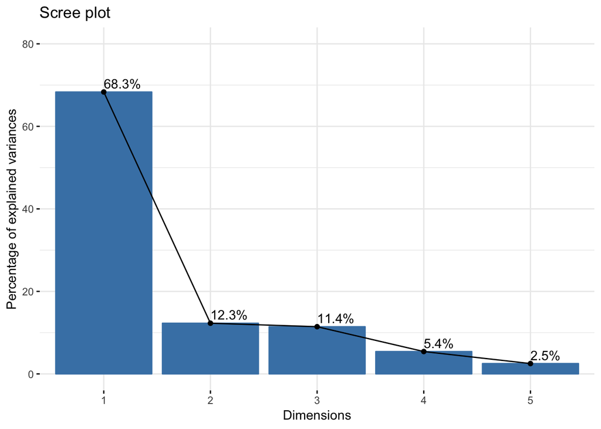

```r
fviz_eig(probe.pca, addlabels = TRUE, ylim = c(0, 80))
```

The scree plot suggest to keep 2 principal components.

### Method 4: Significance of the “larger” components

Test $H_{ok}$: $\gamma_{p-k+1}$ = … = $\gamma_p$ using a likelihood ratio approach. Reject $H_0$ if $u \ge \chi^2_{\alpha,v}$

```
##      Eigenvalue k         u df Crit Value
## [1,]  3.4164933 5 23.971279 14  23.684791
## [2,]  0.6144313 4  5.386313  9  16.918978
## [3,]  0.5722740 3  4.107388  5  11.070498
## [4,]  0.2712115 2  1.084925  2   5.991465
## [5,]  0.1255899 1  0.000000  0   0.000000
```

$H_{03}$: $\gamma_{p-2}$ = $\gamma_{p-1}$ $\gamma_3$ = $\gamma_2$ Fail to reject null hypothesis since $u < \chi^2_{\alpha,v}$

The tests indicate that only the last four (population) eigenvalues are equal and we should retain PC1

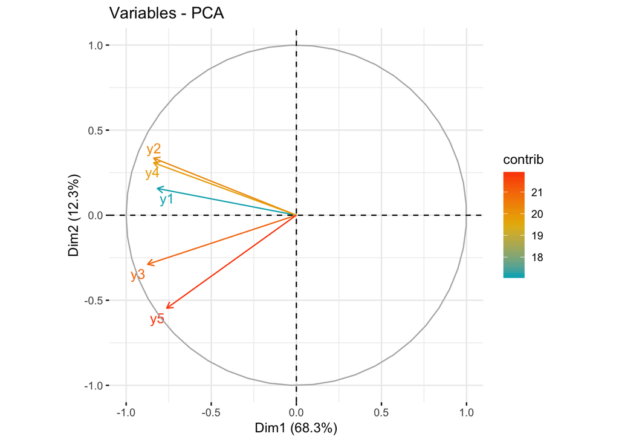

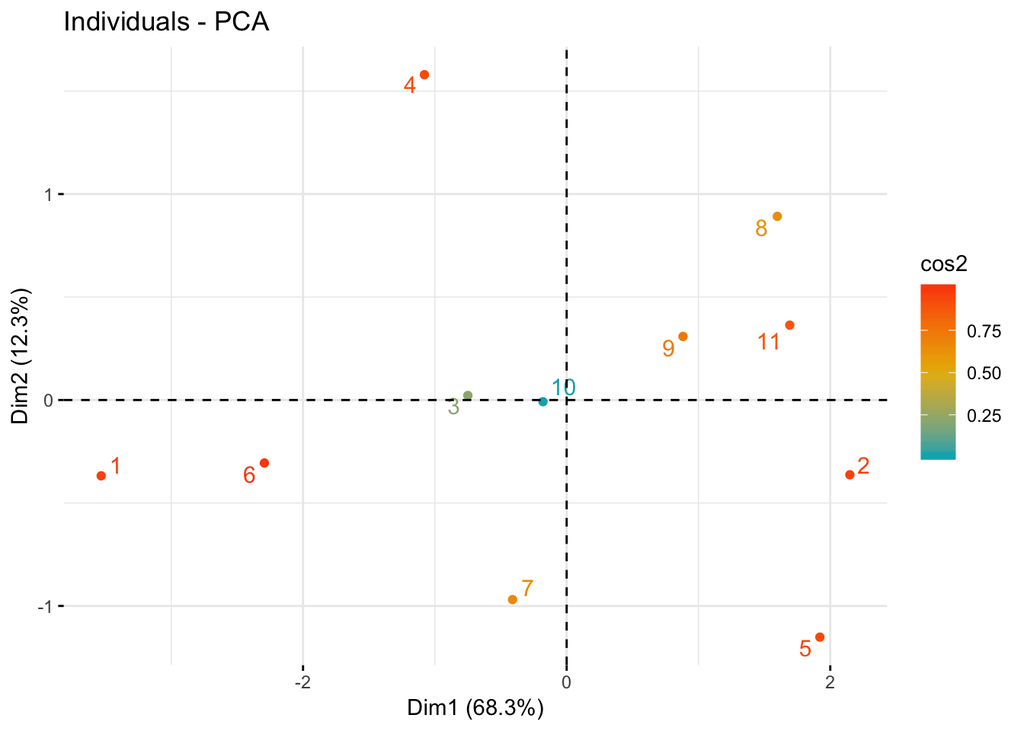

```r
fviz_pca_ind(probe.pca,
             col.ind = "cos2", # Color by the quality of representation
             gradient.cols = c("#00AFBB", "#E7B800", "#FC4E07"),
             repel = TRUE     # Avoid text overlapping
             )
```

Individuals with a similar profile are grouped together.

```
## Principal Components Analysis
## Call: principal(r = pcacor, nfactors = 5, rotate = "none", scores = TRUE)
## Standardized loadings (pattern matrix) based upon correlation matrix
##     PC1   PC2   PC3   PC4   PC5 h2      u2 com
## y1 0.82 -0.16 -0.51  0.11  0.18  1 0.0e+00 1.9
## y2 0.84 -0.34  0.26  0.32 -0.12  1 2.7e-15 1.9
## y3 0.87  0.29 -0.28 -0.13 -0.23  1 2.0e-15 1.7
## y4 0.84 -0.31  0.25 -0.37  0.07  1 1.7e-15 1.9
## y5 0.76  0.55  0.31  0.09  0.14  1 5.6e-16 2.3
##
##                        PC1  PC2  PC3  PC4  PC5
## SS loadings           3.42 0.61 0.57 0.27 0.13
## Proportion Var        0.68 0.12 0.11 0.05 0.03
## Cumulative Var        0.68 0.81 0.92 0.97 1.00
## Proportion Explained  0.68 0.12 0.11 0.05 0.03
## Cumulative Proportion 0.68 0.81 0.92 0.97 1.00
##
## Mean item complexity =  1.9
## Test of the hypothesis that 5 components are sufficient.
##
## The root mean square of the residuals (RMSR) is  0
##
## Fit based upon off diagonal values = 1
```

```
##
## Factor analysis with Call: principal(r = pcacor, nfactors = 5, rotate = "none", scores = TRUE)
##
## Test of the hypothesis that 5 factors are sufficient.
## The degrees of freedom for the model is -5  and the objective function was  0
##
## The root mean square of the residuals (RMSA) is  0
```

```
##
## Reliability analysis
## Call: alpha(x = pcacor)
##
##   raw_alpha std.alpha G6(smc) average_r S/N median_r
##       0.88      0.88     0.9       0.6 7.6     0.59
##
##  Reliability if an item is dropped:
##    raw_alpha std.alpha G6(smc) average_r S/N  var.r med.r
## y1      0.86      0.86    0.85      0.61 6.3 0.0083  0.58
## y2      0.85      0.85    0.85      0.59 5.9 0.0149  0.59
## y3      0.84      0.84    0.81      0.57 5.3 0.0123  0.56
## y4      0.85      0.85    0.87      0.60 5.9 0.0147  0.58
## y5      0.88      0.88    0.87      0.64 7.2 0.0081  0.61
##
##  Item statistics
##       r r.cor r.drop
## y1 0.81  0.78   0.70
## y2 0.84  0.79   0.74
## y3 0.87  0.86   0.79
## y4 0.84  0.78   0.74
## y5 0.77  0.71   0.64
```

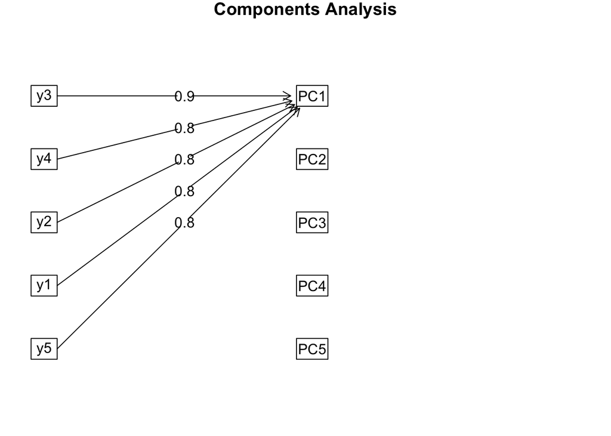

First two principal components for the probe data

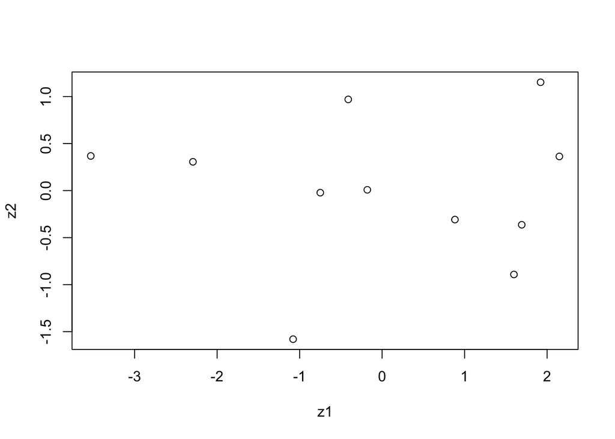

```r
plot(as.matrix(probe.scaled) %*% res.eig$vectors[,1:2], xlab = "z1", ylab = "z2")
```

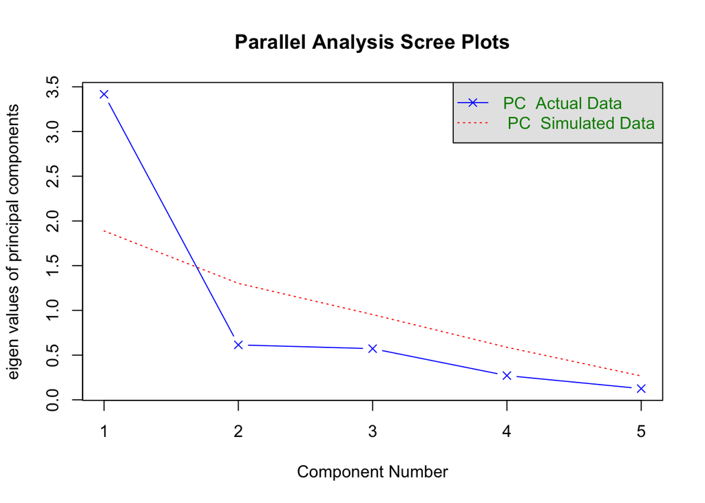

```
## Parallel analysis suggests that the number of factors =  NA  and the number of components =  1
```

```r
fa.parallel(probe.scaled, n.obs = nrow(probe.scaled), fm = "pa", fa = "pc")
```

From this plot, we can see that the first component has the largest eigen value.

## Check assumptions

The KMO test

```
## $KMO
## [1] 0.6914
##
## $MSA
##        MSA
## y1 0.65900
## y2 0.70881
## y3 0.64428
## y4 0.80664
## y5 0.65915
##
## $Bartlett
## [1] 23.971
##
## $Communalities
##    Initial Communalities Final Extraction
## y1               0.68304          0.58306
## y2               0.65501          0.62681
## y3               0.76358          0.72565
## y4               0.61642          0.62917
## y5               0.58793          0.46773
##
## $Factor.Loadings
##       [,1]
## y1 0.76358
## y2 0.79172
## y3 0.85185
## y4 0.79320
## y5 0.68391
##
## $RMS
## [1] 0.085206
```

Test significance of the Bartlett test using correlation matrix

```
## $chisq
## [1] 23.971
##
## $p.value
## [1] 0.007677
##
## $df
## [1] 10
```

The Bartlett chi-square = 23.97128, df = 10, p = 0.00768 is significant indicating correlations in matrix are significant.

```
## [1] 0.040919
```

The determinant is positive. The three assumptions for conducting a principal components analysis have been met.